# Cohort Analysis Online Retail Sample Dataset

## Importing, Cleaning, and Setup

To begin, we will install the packages we need for analysis, cleaning, visualization, etc.

```python
import pandas as pd
import seaborn as sns
import numpy as np
import datetime as dt
import matplotlib.pyplot as plt
import os
```

This bit of code helps us understand what our current directory is and set an active directory to be what we want it to be. Great for importing this code into other tools which may not have intuitive directories.

```python
print(os.getcwd())
path = "F:\[Personal]\Data Analytics Portfolio\Cohort Analysis\online_retail"
os.chdir(path)
print(os.getcwd())
```

```
F:\[Personal]\Data Analytics Portfolio\Cohort Analysis\online_retail
F:\[Personal]\Data Analytics Portfolio\Cohort Analysis\online_retail
```

The dataset contains two CSVs (or one Excel with two sheets). I chose to append them because it's simple but that method is depracated so pd.concat is recommended in the future.

We're also inspecting the data and, most importantly, the datatypes. For this analysis, it's critical that the 'InvoiceDate' column be correctly parsed as datetime.

Below are two methods we use to make sure the datetime imports correctly into any tool. The first of which are the optional arguments included in the pd.read_csv commands. More on the second below.

```python
df1 = pd.read_csv(r'F:\[Personal]\Data Analytics Portfolio\Cohort Analysis\online_retail\online2009_2010.csv',
                  encoding = 'unicode_escape', parse_dates=['InvoiceDate'], infer_datetime_format=True)
df2 = pd.read_csv(r'F:\[Personal]\Data Analytics Portfolio\Cohort Analysis\online_retail\online2010_2011.csv',
                  encoding = 'unicode_escape', parse_dates=['InvoiceDate'], infer_datetime_format=True)
df = df1.append(df2)

print(df.head())
print(df.shape)
print(df.dtypes)

df.isna().sum()
```

```
  Invoice StockCode                          Description  Quantity  \
0  489434     85048  15CM CHRISTMAS GLASS BALL 20 LIGHTS        12
1  489434    79323P                   PINK CHERRY LIGHTS        12
2  489434    79323W                  WHITE CHERRY LIGHTS        12
3  489434     22041         RECORD FRAME 7" SINGLE SIZE         48
4  489434     21232       STRAWBERRY CERAMIC TRINKET BOX        24

          InvoiceDate  Price  Customer ID         Country
0 2009-12-01 07:45:00   6.95      13085.0  United Kingdom
1 2009-12-01 07:45:00   6.75      13085.0  United Kingdom
2 2009-12-01 07:45:00   6.75      13085.0  United Kingdom
3 2009-12-01 07:45:00   2.10      13085.0  United Kingdom
4 2009-12-01 07:45:00   1.25      13085.0  United Kingdom
(1067371, 8)
Invoice                object
StockCode              object
Description            object
Quantity                int64
InvoiceDate    datetime64[ns]
Price                 float64
Customer ID           float64
Country                object
dtype: object
```

```
Invoice             0
StockCode           0
Description      4382
Quantity            0
InvoiceDate         0
Price               0
Customer ID    243007
Country             0
dtype: int64
```

This section of code does two things: ensures a conversion into datetime and cleans the data somewhat.

We instruct pd.to_datetime to both coerce errors, essentially bypassing them where they might pop up and we set utc to be "True" because having datetimes in different offsets (time zones) can create problems in conversion.

This data cleaning isn't strictly necessary in establishing cohorts but I prefer to do it for cleanliness and also to ensure nothing I run later is affected by the negative values observed in both "Quantity" and "Price" fields.

```python
df['InvoiceDate'] = pd.to_datetime(df['InvoiceDate'], errors='coerce', utc = True)

df['Price'] = df['Price'].abs()
print(df['Price'].sort_values(ascending = True))

df['Quantity'] = df['Quantity'].abs()
print(df['Quantity'].sort_values(ascending = True))
```

```
170484        0.00
374514        0.00
374513        0.00
424304        0.00
374512        0.00
            ...
241827    25111.09
403472    38925.87
222681    38970.00
276274    44031.79
179403    53594.36
Name: Price, Length: 1067371, dtype: float64
541909        1
251307        1
124382        1
124383        1
124385        1
          ...
90857     19152
61624     74215
61619     74215
540422    80995
540421    80995
Name: Quantity, Length: 1067371, dtype: int64
```

## Establishing Key Date Functions

Here, we are establishing a function that we will use below which helps us to parse month from the 'InvoiceDate' column. This helps us define cohort and invoice months.

```python
def get_month(x): return dt.datetime(x.year, x.month, 1)
df['InvoiceMonth'] = df['InvoiceDate'].apply(get_month)
grouping = df.groupby('Customer ID')['InvoiceMonth']
df['CohortMonth'] = grouping.transform('min')
print(df.head())
```

```
  Invoice StockCode                          Description  Quantity  \
0  489434     85048  15CM CHRISTMAS GLASS BALL 20 LIGHTS        12
1  489434    79323P                   PINK CHERRY LIGHTS        12
2  489434    79323W                  WHITE CHERRY LIGHTS        12
3  489434     22041         RECORD FRAME 7" SINGLE SIZE         48
4  489434     21232       STRAWBERRY CERAMIC TRINKET BOX        24

                InvoiceDate  Price  Customer ID         Country InvoiceMonth  \
0 2009-12-01 07:45:00+00:00   6.95      13085.0  United Kingdom   2009-12-01
1 2009-12-01 07:45:00+00:00   6.75      13085.0  United Kingdom   2009-12-01
2 2009-12-01 07:45:00+00:00   6.75      13085.0  United Kingdom   2009-12-01
3 2009-12-01 07:45:00+00:00   2.10      13085.0  United Kingdom   2009-12-01
4 2009-12-01 07:45:00+00:00   1.25      13085.0  United Kingdom   2009-12-01

  CohortMonth
0  2009-12-01
1  2009-12-01
2  2009-12-01
3  2009-12-01
4  2009-12-01
```

Here, we establish another function which helps us get the year and month of any dataframe column that we insert into the function.

```python
def get_date_int(df_column):
    year = df_column.dt.year
    month = df_column.dt.month
    return year, month
```

We immediately put the function into practice, having it return Cohort and Invoice years and months.

The next step is to figure out the difference between the invoice dates and the cohort dates, which helps us add 'CohortIndex' to the newly established 'InvoiceMonth' and 'CohortMonth' fields.

```python
invoice_year, invoice_month = get_date_int(df['InvoiceMonth'])
cohort_year, cohort_month = get_date_int(df['CohortMonth'])
years_diff = invoice_year - cohort_year
months_diff = invoice_month - cohort_month
df['CohortIndex'] = years_diff * 12 + months_diff + 1
df.head()
```

|  | Invoice | StockCode | Description | Quantity | InvoiceDate | Price | Customer ID | Country | InvoiceMonth | CohortMonth | CohortIndex |
| --- | --- | --- | --- | --- | --- | --- | --- | --- | --- | --- | --- |
| 0 | 489434 | 85048 | 15CM CHRISTMAS GLASS BALL 20 LIGHTS | 12 | 2009-12-01 07:45:00+00:00 | 6.95 | 13085.0 | United Kingdom | 2009-12-01 | 2009-12-01 | 1.0 |
| 1 | 489434 | 79323P | PINK CHERRY LIGHTS | 12 | 2009-12-01 07:45:00+00:00 | 6.75 | 13085.0 | United Kingdom | 2009-12-01 | 2009-12-01 | 1.0 |
| 2 | 489434 | 79323W | WHITE CHERRY LIGHTS | 12 | 2009-12-01 07:45:00+00:00 | 6.75 | 13085.0 | United Kingdom | 2009-12-01 | 2009-12-01 | 1.0 |
| 3 | 489434 | 22041 | RECORD FRAME 7" SINGLE SIZE | 48 | 2009-12-01 07:45:00+00:00 | 2.10 | 13085.0 | United Kingdom | 2009-12-01 | 2009-12-01 | 1.0 |
| 4 | 489434 | 21232 | STRAWBERRY CERAMIC TRINKET BOX | 24 | 2009-12-01 07:45:00+00:00 | 1.25 | 13085.0 | United Kingdom | 2009-12-01 | 2009-12-01 | 1.0 |

## Establishing Cohorts and Data Processing

This is where things get interesting. We're establishing a grouping that lets us better sort the data by Cohort Month and Index.

We're defining some column names for better readability and finally establishing a pivot table with the cohort fields and the 'Customer ID' field. Think of this as a preliminary cohort in tabular format.

```python
grouping = df.groupby(['CohortMonth', 'CohortIndex'])
cohort_data = grouping['Customer ID'].apply(pd.Series.nunique).reset_index()
cohort_data.columns = ['CohortMonth', 'CohortIndex', 'Count of unique Customer ID']
retention_counts = cohort_data.pivot(index = 'CohortMonth', columns = 'CohortIndex', values = 'Count of unique Customer ID')
print(retention_counts.head())
```

```
CohortIndex    1.0    2.0    3.0    4.0    5.0    6.0    7.0    8.0    9.0   \
CohortMonth
2009-12-01   1045.0  392.0  358.0  447.0  410.0  408.0  408.0  374.0  355.0
2010-01-01    394.0   86.0  119.0  120.0  110.0  115.0  105.0   91.0  114.0
2010-02-01    363.0  109.0   82.0  110.0   93.0   76.0   79.0  103.0  100.0
2010-03-01    436.0   95.0  113.0  103.0  100.0   87.0  105.0  130.0  126.0
2010-04-01    291.0   67.0   58.0   47.0   54.0   67.0   79.0   76.0   33.0

CohortIndex   10.0  ...   16.0   17.0   18.0   19.0   20.0   21.0   22.0  \
CohortMonth         ...
2009-12-01   392.0  ...  319.0  273.0  316.0  303.0  287.0  274.0  332.0
2010-01-01   134.0  ...   60.0   86.0   74.0   69.0   73.0   93.0   73.0
2010-02-01   106.0  ...   74.0   67.0   61.0   53.0   85.0   90.0   62.0
2010-03-01    50.0  ...   74.0   76.0   69.0   74.0   89.0   93.0   33.0
2010-04-01    34.0  ...   43.0   41.0   41.0   50.0   61.0   19.0    NaN

CohortIndex   23.0   24.0   25.0
CohortMonth
2009-12-01   319.0  427.0  218.0
2010-01-01    88.0   29.0    NaN
2010-02-01    23.0    NaN    NaN
2010-03-01     NaN    NaN    NaN
2010-04-01     NaN    NaN    NaN

[5 rows x 25 columns]
```

It's important to establish the following if we want to look at retention rates in the cohorts. We're getting the size of the cohorts by counting the first column of the retention pivot table.

We then use that to divide across rows (axis = 0 as opposed to 1 for columns) and apply some rounding to make the field more readable. Stay tuned for the output!

```python
cohort_sizes = retention_counts.iloc[:,0]
retention = retention_counts.divide(cohort_sizes, axis = 0)
retention = retention.round(3)
```

We're employing a similar technique to the above in order to see a cohort pivot based on 'Quantity'.

```python
grouping = df.groupby(['CohortMonth', 'CohortIndex'])
cohort_data = grouping['Quantity'].mean()
cohort_data = cohort_data.reset_index()
average_quantity = cohort_data.pivot(index = 'CohortMonth', columns = 'CohortIndex', values = 'Quantity')
average_quantity.round(1)
print(average_quantity)
```

```
CohortIndex       1.0        2.0        3.0        4.0        5.0        6.0   \
CohortMonth
2009-12-01   12.912972  22.392774  21.002176  21.545624  13.489181  15.524853
2010-01-01    9.127481  12.959646   9.310018  12.699391  11.440364  11.780553
2010-02-01    9.824130   9.544484  15.465889  12.873996   9.961326  11.856862
2010-03-01   10.050794  14.106752  12.363773  16.483107  11.027831  16.003225
2010-04-01   10.483552   9.090211   9.251445  14.830010  12.915596  10.788171
2010-05-01   12.026839  10.114416  10.121827  12.415094  12.768493   9.234390
2010-06-01   10.890266   8.492754  13.273333  10.518919  10.964965  14.014423
2010-07-01    8.450731   9.741135   6.935619   8.494375   7.100095   6.770413
2010-08-01    8.027181   8.408827   8.678806   7.527053  11.092126   7.532110
2010-09-01   26.611814  12.039925   8.200000  11.223731  15.778833   7.881416
2010-10-01    8.814993   5.978168   6.642483   9.759259   6.793619   5.119891
2010-11-01    7.747814   8.340299  11.846633   8.061026   7.671937   9.593243
2010-12-01    7.157130   9.152174  27.830645   7.684932  15.864322   4.186207
2011-01-01   11.854582   4.591837   5.163683  76.079710  11.118605  11.288754
2011-02-01   10.073135  18.539535  37.074797   9.797158  12.005556   7.878104
2011-03-01    9.179201  11.681360  15.765317   9.047284  14.790343  12.684564
2011-04-01    8.600313   8.869448   6.575318   9.063098   7.736842   8.443137
2011-05-01   10.111972  10.612782  13.744722  13.268882  10.802432   8.873239
2011-06-01    9.430696  17.115506  10.212963  12.971178   9.548159   9.800857
2011-07-01    8.949741  12.350785   6.444840   7.538911   5.838122   7.078014
2011-08-01    9.517952   6.008270   4.979056   5.659867   6.738922        NaN
2011-09-01   10.712862   6.454060   8.083259   8.020672        NaN        NaN
2011-10-01    8.688452   7.271842   8.035336        NaN        NaN        NaN
2011-11-01   10.287438  10.268349        NaN        NaN        NaN        NaN
2011-12-01   19.736600        NaN        NaN        NaN        NaN        NaN

CohortIndex       7.0        8.0        9.0        10.0  ...       16.0  \
CohortMonth                                              ...
2009-12-01   14.009239  14.098430  24.418046  22.806182  ...  15.284899
2010-01-01   10.625257  12.507528  11.080238  13.870807  ...  13.706250
2010-02-01   11.885811  10.243604   9.455748  10.670219  ...  11.435616
2010-03-01   14.335674  12.695394  11.356984  16.073462  ...  10.500566
2010-04-01    9.898980   9.457207   8.988688  10.202051  ...  12.882159
2010-05-01    7.282660   6.212199  11.038690  11.399491  ...  11.381748
2010-06-01   11.262019  17.495922  31.331407  28.796662  ...  18.551336
2010-07-01    8.179732   9.341121   7.617992   7.098972  ...   8.189272
2010-08-01    8.181818   7.779904  12.611446  15.644764  ...  10.920354
2010-09-01   13.459770  11.932039  19.327476  14.425676  ...   9.643791
```

[output cut: 58 more lines]

```
2010-12-01         NaN        NaN      NaN
2011-01-01         NaN        NaN      NaN
2011-02-01         NaN        NaN      NaN
2011-03-01         NaN        NaN      NaN
2011-04-01         NaN        NaN      NaN
2011-05-01         NaN        NaN      NaN
2011-06-01         NaN        NaN      NaN
2011-07-01         NaN        NaN      NaN
2011-08-01         NaN        NaN      NaN
2011-09-01         NaN        NaN      NaN
2011-10-01         NaN        NaN      NaN
2011-11-01         NaN        NaN      NaN
2011-12-01         NaN        NaN      NaN

[25 rows x 25 columns]
```

## Visualizing Retention Rates in the Cohort

This is the moment of truth. We have flexibility in what we visualize but retention rate is what matters the most. This Seaborn Heatmap plot lets us see two years' worth of cohort data and we can instantly see which cohorts performed better.

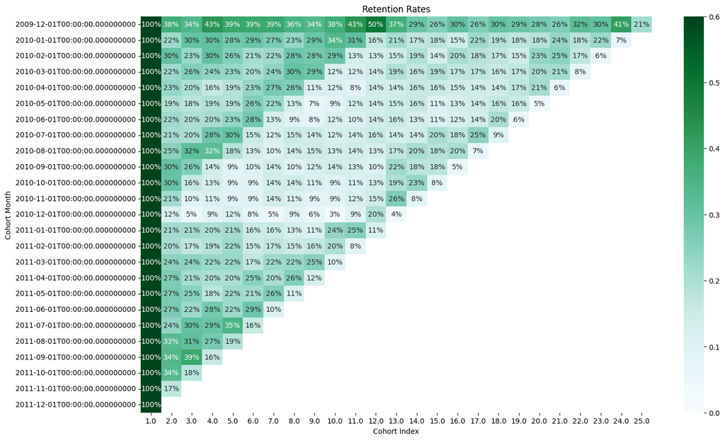

```python
plt.figure(figsize=(16,10))
plt.title('Retention Rates')
sns.heatmap(data = retention, annot = True, fmt = '.0%', vmin = 0.0, vmax = 0.6, cmap = 'BuGn')
plt.ylabel('Cohort Month')
plt.xlabel('Cohort Index')
plt.show()
```

### Thanks for reading this. Just a brief note that our work here isn't exclusive and can (and will) be combined with RFM analysis to form a more complete picture. See my portfolio for a link to that.